# Modelos de forecasting globales: modelado de múltiples series temporales con machine learning

**Joaquín Amat Rodrigo, Javier Escobar Ortiz**

*Octubre 2022 (última actualización Agosto 2024)*

Más sobre ciencia de datos: [**cienciadedatos.net**](https://cienciadedatos.net)

- [Forecasting series temporales con machine learning](https://www.cienciadedatos.net/documentos/py27-forecasting-series-temporales-python-scikitlearn.html)
- [Modelos ARIMA y SARIMAX](https://cienciadedatos.net/documentos/py51-modelos-arima-sarimax-python.html)
- [Forecasting series temporales con gradient boosting: XGBoost, LightGBM y CatBoost](https://www.cienciadedatos.net/documentos/py39-forecasting-series-temporales-con-skforecast-xgboost-lightgbm-catboost.html)
- [Global Forecasting: Multi-series forecasting](https://www.cienciadedatos.net/documentos/py44-multi-series-forecasting-skforecast-espa%C3%B1ol.html)
- [Forecasting de la demanda eléctrica con machine learning](https://www.cienciadedatos.net/documentos/py29-forecasting-demanda-energia-electrica-python.html)
- [Forecasting con deep learning](https://cienciadedatos.net/documentos/py54-forecasting-con-deep-learning)
- [Forecasting de visitas a página web con machine learning](https://www.cienciadedatos.net/documentos/py37-forecasting-visitas-web-machine-learning.html)
- [Forecasting del precio de Bitcoin](https://www.cienciadedatos.net/documentos/py41-forecasting-criptomoneda-bitcoin-machine-learning-python.html)
- [Forecasting probabilístico](https://cienciadedatos.net/documentos/py42-forecasting-probabilistico.html)
- [Forecasting de demanda intermitente](https://www.cienciadedatos.net/documentos/py48-forecasting-demanda-intermitente.html)
- [Reducir el impacto del Covid en modelos de forecasting](https://www.cienciadedatos.net/documentos/py45-weighted-time-series-forecasting-es.html)
- [Modelar series temporales con tendencia utilizando modelos de árboles](https://www.cienciadedatos.net/documentos/py49-modelar-tendencia-en-series-temporales-modelos-de-arboles.html)

[figure not shown]

## Modelos de forecasting globales

En los **modelos de series individuales (*Local Forecasting Model*)**, una única serie temporal se modela como una combinación lineal o no lineal de sus valores pasados y, opcionalmente, variables exógenas. Aunque este método proporciona una comprensión exhaustiva de cada serie, su escalabilidad puede verse comprometida cuando se dispone de un gran número de series.

**Los modelos globales multiserie (*Global Forecasting Model*)** consisten en un único modelo que tiene en cuenta varias series temporales de forma simultánea. Intentan captar los patrones básicos que rigen las series, mitigando así el ruido potencial que pueda introducir cada serie. Este enfoque es eficiente desde el punto de vista computacional, es fácil de mantener y puede conseguir mayor generalización, aunque potencialmente a costa de sacrificar cierta resolución individual. Se pueden distinguir dos estrategias de modelos de previsión global: Múltiples series temporales independientes y Múltiples series temporales dependientes.

Ventajas de los modelos multiseries

- Es más fácil mantener y controlar un solo modelo que varios.
- Dado que todas las series temporales se combinan durante el entrenamiento, cuando las series sean cortas (pocos datos) el modelo tendrá una mayor capacidad de aprendizaje al disponer de más observaciones.
- Al combinar múltiples series temporales, el modelo puede aprender patrones más generalizables.

Desventajas de los modelos multiseries

- Si las series no siguen la misma dinámica interna, el modelo puede aprender un patrón que no represente a ninguna de ellas.
- Las series pueden enmascararse unas a otras, por lo que el modelo puede no predecirlas todas con el mismo rendimiento.
- Es más exigente desde el punto de vista computacional (tiempo y recursos) entrenar y realizar [*backtesting*](https://skforecast.org/latest/user_guides/backtesting.html) de un modelo grande que de varios pequeños.

**Múltiples series temporales independientes**

En esta situación, cada serie temporal es independiente de las demás o, dicho de otro modo, los valores pasados de una serie no se utilizan como predictores de las otras series. ¿Por qué es útil entonces modelar todo junto? Aunque las series no dependen unas de otras, pueden seguir el mismo patrón intrínseco en cuanto a sus valores pasados y futuros. Por ejemplo, en una misma tienda, las ventas de los productos A y B pueden no estar relacionadas, pero siguen la misma dinámica, la de la tienda.

[figure not shown]

Para predecir los siguientes *n steps*, se sigue una estrategia recurisva, [recursive multi-step forecasting](https://skforecast.org/latest/introduction-forecasting/introduction-forecasting.html#recursive-multi-step-forecasting).

[figure not shown]

**Múltiples series temporales dependientes**

Todas las series se modelan teniendo en cuenta que cada serie temporal depende no sólo de sus valores pasados, sino también de los valores pasados de las demás series. Se espera que el modelo no sólo aprenda la información de cada serie por separado, sino que también las relacione. Por ejemplo, las mediciones realizadas por todos los sensores (caudal, temperatura, presión...) instalados en una máquina industrial como un compresor. [Series temporales multivariantes user guide](https://skforecast.org/latest/user_guides/dependent-multi-series-multivariate-forecasting.html).

[figure not shown]

**💡 Tip**

Este es el primero de una serie de documentos sobre modelos de forecasting globales:

- [odelos de forecasting globales: modelado de múltiples series temporales con machine learning](https://cienciadedatos.net/documentos/py44-multi-series-forecasting-skforecast-espa%C3%B1ol.html)
- [Forecasting escalable: modelado de mil de series temporales con un único modelo global](https://www.cienciadedatos.net/documentos/py59-modelos-forecasting-escalables.html)
- [Modelos de forecasting globales: Análisis comparativo de modelos de una y múltiples series](https://cienciadedatos.net/documentos/py53-modelos-forecasting-globales.html)

## Series con la misma longitud

En este primer ejemplo, se utilizan múltiples series temporales de la misma longitud. El objetivo es comparar los resultados de un modelo global con los de un modelo individual para cada serie al predecir los próximos 7 días de ventas para 50 productos diferentes en una tienda, utilizando los 5 años de historial disponible. Los datos se han obtenido del [Store Item Demand Forecasting Challenge](https://www.kaggle.com/c/demand-forecasting-kernels-only/data). Este conjunto de datos contiene 913,000 transacciones de ventas desde el 01/01/2013 hasta el 31/12/2017 para 50 productos (SKU) en 10 tiendas.

### Librerías

```python
# Manipulación de datos
# ==============================================================================
import numpy as np
import pandas as pd

# Gráficos
# ==============================================================================
import matplotlib.pyplot as plt
from tqdm.notebook import tqdm

# Modelado y Forecasting
# ==============================================================================
import sklearn
import skforecast
from sklearn.ensemble import HistGradientBoostingRegressor
from sklearn.preprocessing import StandardScaler
from sklearn.feature_selection import RFECV
from skforecast.recursive import ForecasterRecursiveMultiSeries
from skforecast.recursive import ForecasterRecursive
from skforecast.model_selection import TimeSeriesFold, OneStepAheadFold
from skforecast.model_selection import backtesting_forecaster
from skforecast.model_selection import bayesian_search_forecaster
from skforecast.model_selection import backtesting_forecaster_multiseries
from skforecast.model_selection import bayesian_search_forecaster_multiseries
from skforecast.feature_selection import select_features_multiseries
from skforecast.preprocessing import RollingFeatures
from skforecast.exceptions import OneStepAheadValidationWarning
from skforecast.plot import set_dark_theme
from skforecast.preprocessing import series_long_to_dict
from skforecast.preprocessing import exog_long_to_dict

# Warnings
# ==============================================================================
import warnings
warnings.filterwarnings('once')

color = '\033[1m\033[38;5;208m'
print(f"{color}Versión skforecast: {skforecast.__version__}")
print(f"{color}Versión scikit-learn: {sklearn.__version__}")
print(f"{color}Versión pandas: {pd.__version__}")
print(f"{color}Versión numpy: {np.__version__}")
```

```
Versión skforecast: 0.14.0
Versión scikit-learn: 1.5.1
Versión pandas: 2.2.3
Versión numpy: 2.0.2
```

### Datos

```python
# Lectura de datos
# ======================================================================================
data = pd.read_csv('./train_stores_kaggle.csv')
display(data)
print(f"Shape: {data.shape}")
```

|  | date | store | item | sales |
| --- | --- | --- | --- | --- |
| 0 | 2013-01-01 | 1 | 1 | 13 |
| 1 | 2013-01-02 | 1 | 1 | 11 |
| 2 | 2013-01-03 | 1 | 1 | 14 |
| 3 | 2013-01-04 | 1 | 1 | 13 |
| 4 | 2013-01-05 | 1 | 1 | 10 |
| ... | ... | ... | ... | ... |
| 912995 | 2017-12-27 | 10 | 50 | 63 |
| 912996 | 2017-12-28 | 10 | 50 | 59 |
| 912997 | 2017-12-29 | 10 | 50 | 74 |
| 912998 | 2017-12-30 | 10 | 50 | 62 |
| 912999 | 2017-12-31 | 10 | 50 | 82 |

913000 rows × 4 columns

```
Shape: (913000, 4)
```

```python
# Preparación datos
# ======================================================================================
selected_store = 2 # Seleccionar una tienda
selected_items = data.item.unique()
data = data[(data['store'] == selected_store) & (data['item'].isin(selected_items))].copy()
data['date'] = pd.to_datetime(data['date'], format='%Y-%m-%d')
data = pd.pivot_table(
           data    = data,
           values  = 'sales',
           index   = 'date',
           columns = 'item'
       )
data.columns.name = None
data.columns = [f"item_{col}" for col in data.columns]
data = data.asfreq('1D')
data = data.sort_index()
data.head(4)
```

| date | item_1 | item_2 | item_3 | item_4 | item_5 | item_6 | item_7 | item_8 | item_9 | item_10 | ... | item_41 | item_42 | item_43 | item_44 | item_45 | item_46 | item_47 | item_48 | item_49 | item_50 |
| --- | --- | --- | --- | --- | --- | --- | --- | --- | --- | --- | --- | --- | --- | --- | --- | --- | --- | --- | --- | --- | --- |
| 2013-01-01 | 12.0 | 41.0 | 19.0 | 21.0 | 4.0 | 34.0 | 39.0 | 49.0 | 28.0 | 51.0 | ... | 11.0 | 25.0 | 36.0 | 12.0 | 45.0 | 43.0 | 12.0 | 45.0 | 29.0 | 43.0 |
| 2013-01-02 | 16.0 | 33.0 | 32.0 | 14.0 | 6.0 | 40.0 | 47.0 | 42.0 | 21.0 | 56.0 | ... | 19.0 | 21.0 | 35.0 | 25.0 | 50.0 | 52.0 | 13.0 | 37.0 | 25.0 | 57.0 |
| 2013-01-03 | 16.0 | 46.0 | 26.0 | 12.0 | 12.0 | 41.0 | 43.0 | 46.0 | 29.0 | 46.0 | ... | 23.0 | 20.0 | 52.0 | 18.0 | 56.0 | 30.0 | 5.0 | 45.0 | 30.0 | 45.0 |
| 2013-01-04 | 20.0 | 50.0 | 34.0 | 17.0 | 16.0 | 41.0 | 44.0 | 55.0 | 32.0 | 56.0 | ... | 15.0 | 28.0 | 50.0 | 24.0 | 57.0 | 46.0 | 19.0 | 32.0 | 20.0 | 45.0 |

4 rows × 50 columns

El dataset se divide en 3 particiones: una para el entrenamiento, otra para la validación y otra para test.

```python
# Separación datos train-validation-test
# ======================================================================================
end_train = '2016-05-31 23:59:00'
end_val = '2017-05-31 23:59:00'
data_train = data.loc[:end_train, :].copy()
data_val   = data.loc[end_train:end_val, :].copy()
data_test  = data.loc[end_val:, :].copy()
print(f"Fechas train      : {data_train.index.min()} --- {data_train.index.max()}  (n={len(data_train)})")
print(f"Fechas validación : {data_val.index.min()} --- {data_val.index.max()}  (n={len(data_val)})")
print(f"Fechas test       : {data_test.index.min()} --- {data_test.index.max()}  (n={len(data_test)})")
```

```
Fechas train      : 2013-01-01 00:00:00 --- 2016-05-31 00:00:00  (n=1247)
Fechas validación : 2016-06-01 00:00:00 --- 2017-05-31 00:00:00  (n=365)
Fechas test       : 2017-06-01 00:00:00 --- 2017-12-31 00:00:00  (n=214)
```

Se representan cuatro de las series para comprender sus tendencias y patrones. Se recomienda al lector que grafique más de ellas para comprenderlas en profundidad.

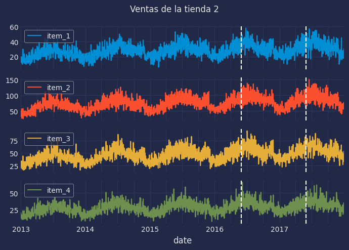

```python
# Gráfico series temporales
# ======================================================================================
set_dark_theme()
fig, axs = plt.subplots(4, 1, figsize=(7, 5), sharex=True)
data.iloc[:, :4].plot(
    legend   = True,
    subplots = True,
    title    = 'Ventas de la tienda 2',
    ax       = axs,
)
for ax in axs:
    ax.axvline(pd.to_datetime(end_train) , color='white', linestyle='--', linewidth=1.5)
    ax.axvline(pd.to_datetime(end_val) , color='white', linestyle='--', linewidth=1.5)
fig.tight_layout();
```

### Forecasting individual para cada item

Se entrena un modelo *Gradient Boosting Machine (GBM)* para cada producto, utilizando las ventas de los últimos 14 días, así como las ventas promedio, máxima y mínima de los últimos 7 días como predictores. El rendimiento del modelo para los siguientes 7 días se evalúa mediante backtesting utilizando el Error Absoluto Medio (MAE) como métrica de evaluación. Finalmente, se compara el rendimiento de estos modelos individuales con el de un modelo global entrenado con todas las series.

```python
# Entrenar y realizar backtesting de un modelo para cada item
# ======================================================================================
items = []
mae_values = []
predictions = {}

for i, item in enumerate(tqdm(data.columns)):
    # Definir el forecaster
    window_features = RollingFeatures(stats=['mean', 'min', 'max'], window_sizes=7)
    forecaster = ForecasterRecursive(
                     regressor       = HistGradientBoostingRegressor(random_state=8523),
                     lags            = 14,
                     window_features = window_features
                 )
    # Backtesting forecaster
    cv = TimeSeriesFold(
            steps              = 7,
            initial_train_size = len(data_train) + len(data_val),
            refit              = False,
         )
    metric, preds = backtesting_forecaster(
                        forecaster    = forecaster,
                        y             = data[item],
                        cv            = cv,
                        metric        = 'mean_absolute_error',
                        verbose       = False,
                        show_progress = False
                    )
    items.append(item)
    mae_values.append(metric.at[0, 'mean_absolute_error'])
    predictions[item] = preds

# Resultados
uni_series_mae = pd.Series(
                     data  = mae_values,
                     index = items,
                     name  = 'uni_series_mae'
                 )
uni_series_mae.head()
```

```
item_1    6.004406
item_2    9.994352
item_3    8.652751
item_4    5.528955
item_5    5.096925
Name: uni_series_mae, dtype: float64
```

### Modelo global: Forecasting multiseries

Se entrena modelo global con las mismas características que los modelos individuales. Se evalúa el rendimiento del modelo global en el conjunto de test y se compara con el rendimiento de los modelos individuales.

```python
# Entrenamiento y backtesting con un único modelo para todos los items
# ======================================================================================
items = list(data.columns)

# Definir el forecaster
window_features = RollingFeatures(stats=['mean', 'min', 'max'], window_sizes=7)
forecaster_ms = ForecasterRecursiveMultiSeries(
                    regressor          = HistGradientBoostingRegressor(random_state=8523),
                    lags               = 14,
                    encoding           = 'ordinal',
                    transformer_series = StandardScaler(),
                    window_features    = window_features,
                )
# Backtesting forecaster para todos los items
cv = TimeSeriesFold(
            steps              = 7,
            initial_train_size = len(data_train) + len(data_val),
            refit              = False,
         )
multi_series_mae, predictions_ms = backtesting_forecaster_multiseries(
                                       forecaster            = forecaster_ms,
                                       series                = data,
                                       levels                = items,
                                       cv                    = cv,
                                       metric                = 'mean_absolute_error',
                                       add_aggregated_metric = False,
                                       verbose               = False,
                                       show_progress         = True
                                   )
# Resultados
display(multi_series_mae.head(3))
print('')
display(predictions_ms.head(3))
```

|  | levels | mean_absolute_error |
| --- | --- | --- |
| 0 | item_1 | 5.521236 |
| 1 | item_2 | 9.245126 |
| 2 | item_3 | 7.301948 |

|  | item_1 | item_2 | item_3 | item_4 | item_5 | item_6 | item_7 | item_8 | item_9 | item_10 | ... | item_41 | item_42 | item_43 | item_44 | item_45 | item_46 | item_47 | item_48 | item_49 | item_50 |
| --- | --- | --- | --- | --- | --- | --- | --- | --- | --- | --- | --- | --- | --- | --- | --- | --- | --- | --- | --- | --- | --- |
| 2017-06-01 | 35.106861 | 90.367217 | 60.613740 | 34.796786 | 30.344390 | 94.850880 | 92.222349 | 125.069804 | 85.972618 | 121.856981 | ... | 36.761204 | 58.301875 | 79.983903 | 43.559158 | 127.045573 | 98.774219 | 37.078906 | 77.610719 | 49.004847 | 109.749311 |
| 2017-06-02 | 38.663113 | 101.583964 | 63.187115 | 35.903646 | 31.293313 | 100.855224 | 97.763251 | 134.804295 | 92.259393 | 121.838499 | ... | 40.470627 | 59.746983 | 85.748729 | 50.961104 | 137.746852 | 102.729668 | 42.124969 | 83.469452 | 53.310940 | 116.044636 |
| 2017-06-03 | 38.264879 | 103.619330 | 65.602129 | 40.237811 | 33.283988 | 107.100882 | 101.806627 | 144.945584 | 94.686035 | 133.521963 | ... | 41.592844 | 64.585156 | 90.099446 | 51.959348 | 141.979401 | 107.639900 | 41.524414 | 89.363027 | 46.842094 | 117.288006 |

3 rows × 50 columns

### Comparación

```python
# Diferencia de la métrica de backtesting para cada item
# ======================================================================================
multi_series_mae = multi_series_mae.set_index('levels')
multi_series_mae.columns = ['multi_series_mae']
results = pd.concat((uni_series_mae, multi_series_mae), axis = 1)
results['improvement'] = results.eval('uni_series_mae - multi_series_mae')
results['improvement_(%)'] = 100 * results.eval('(uni_series_mae - multi_series_mae) / uni_series_mae')
results = results.round(2)
results.style.bar(subset=['improvement_(%)'], align='mid', color=['#d65f5f', '#5fba7d'])
```

|  | uni_series_mae | multi_series_mae | improvement | improvement_(%) |
| --- | --- | --- | --- | --- |
| item_1 | 6.000000 | 5.520000 | 0.480000 | 8.050000 |
| item_2 | 9.990000 | 9.250000 | 0.750000 | 7.500000 |
| item_3 | 8.650000 | 7.300000 | 1.350000 | 15.610000 |
| item_4 | 5.530000 | 5.030000 | 0.500000 | 8.960000 |
| item_5 | 5.100000 | 4.660000 | 0.440000 | 8.630000 |
| item_6 | 10.830000 | 9.750000 | 1.080000 | 9.960000 |
| item_7 | 10.580000 | 9.830000 | 0.750000 | 7.120000 |
| item_8 | 11.810000 | 10.420000 | 1.400000 | 11.830000 |
| item_9 | 9.420000 | 8.690000 | 0.730000 | 7.760000 |
| item_10 | 11.640000 | 10.330000 | 1.300000 | 11.210000 |
| item_11 | 11.520000 | 10.430000 | 1.090000 | 9.450000 |
| item_12 | 11.960000 | 10.890000 | 1.080000 | 8.990000 |
| item_13 | 12.130000 | 11.360000 | 0.760000 | 6.300000 |
| item_14 | 10.350000 | 9.560000 | 0.790000 | 7.610000 |
| item_15 | 12.460000 | 11.640000 | 0.820000 | 6.620000 |
| item_16 | 6.000000 | 5.920000 | 0.090000 | 1.480000 |
| item_17 | 7.460000 | 7.190000 | 0.270000 | 3.560000 |
| item_18 | 12.690000 | 12.120000 | 0.570000 | 4.490000 |
| item_19 | 7.720000 | 7.370000 | 0.360000 | 4.600000 |
| item_20 | 8.250000 | 7.830000 | 0.420000 | 5.080000 |
| item_21 | 8.580000 | 8.060000 | 0.520000 | 6.080000 |
| item_22 | 11.790000 | 10.710000 | 1.080000 | 9.150000 |
| item_23 | 7.490000 | 6.770000 | 0.720000 | 9.600000 |
| item_24 | 10.470000 | 9.860000 | 0.610000 | 5.850000 |
| item_25 | 12.950000 | 11.650000 | 1.310000 | 10.100000 |
| item_26 | 9.230000 | 8.590000 | 0.640000 | 6.930000 |
| item_27 | 5.480000 | 5.170000 | 0.310000 | 5.680000 |
| item_28 | 12.590000 | 12.080000 | 0.510000 | 4.020000 |
| item_29 | 10.980000 | 10.180000 | 0.810000 | 7.330000 |
| item_30 | 8.430000 | 7.890000 | 0.530000 | 6.290000 |
| item_31 | 10.530000 | 10.070000 | 0.460000 | 4.420000 |
| item_32 | 9.710000 | 9.160000 | 0.540000 | 5.580000 |
| item_33 | 9.740000 | 9.320000 | 0.420000 | 4.270000 |
| item_34 | 6.340000 | 5.930000 | 0.410000 | 6.450000 |
| item_35 | 11.200000 | 10.180000 | 1.020000 | 9.120000 |
| item_36 | 12.000000 | 10.620000 | 1.380000 | 11.520000 |
| item_37 | 6.510000 | 6.110000 | 0.400000 | 6.150000 |
| item_38 | 11.620000 | 11.130000 | 0.500000 | 4.270000 |
| item_39 | 8.340000 | 7.370000 | 0.970000 | 11.680000 |
| item_40 | 7.100000 | 6.630000 | 0.470000 | 6.650000 |
| item_41 | 5.670000 | 5.220000 | 0.450000 | 7.950000 |
| item_42 | 7.440000 | 6.940000 | 0.500000 | 6.680000 |
| item_43 | 8.620000 | 8.570000 | 0.050000 | 0.540000 |
| item_44 | 6.980000 | 6.410000 | 0.570000 | 8.190000 |
| item_45 | 12.720000 | 11.790000 | 0.930000 | 7.310000 |
| item_46 | 10.350000 | 9.890000 | 0.460000 | 4.450000 |
| item_47 | 5.500000 | 4.980000 | 0.520000 | 9.500000 |
| item_48 | 9.270000 | 8.190000 | 1.090000 | 11.740000 |
| item_49 | 6.300000 | 5.960000 | 0.340000 | 5.350000 |
| item_50 | 11.860000 | 10.610000 | 1.250000 | 10.510000 |

```python
# Mejora media de todos los items
# ======================================================================================
results[['improvement', 'improvement_(%)']].agg(['mean', 'min', 'max'])
```

|  | improvement | improvement_(%) |
| --- | --- | --- |
| mean | 0.696 | 7.3634 |
| min | 0.050 | 0.5400 |
| max | 1.400 | 15.6100 |

```python
# Número de series con mejora positiva y negativa
# ======================================================================================
pd.Series(np.where(results['improvement_(%)'] < 0, 'negative', 'positive')).value_counts()
```

```
positive    50
Name: count, dtype: int64
```

El modelo global logra una mejora media del 7.4% en comparación con el uso de un modelo individual para cada serie. Para todas las series, el error de predicción evaluado mediante backtesting es menor cuando se utiliza el modelo global. Este caso de uso demuestra que un modelo multiserie puede tener ventajas sobre varios modelos individuales a la hora de predecir series temporales que siguen una dinámica similar. Además de las mejoras potenciales en la predicción, también es importante tener en cuenta el beneficio de tener un único modelo que mantener y la velocidad de entrenamiento y predicción.

**⚠ Warning**

Esta comparación se ha realizado sin optimizar los hiperparámetros del modelo. Consulte la sección *Ajuste de hiperparámetros y selección de lags* para comprobar que las conclusiones se mantienen cuando los modelos se ajustan con la mejor combinación de hiperparámetros y lags.

## Series de diferente longitud y distintas variables exógenas

En escenarios en los que se tienen que modelar múltiples series, es habitual que las series tengan longitudes distintas debido a diferencias en los momentos de inicio del registro de los datos. Para hacer frente a este escenario, la clase [ForecasterAutoregMultiSeries](https://skforecast.org/latest/user_guides/independent-multi-time-series-forecasting) permite modelizar simultáneamente series temporales de distintas longitudes y con distintas variables exógenas.

- Cuando las series modeladas tienen longitudes diferentes, deben almacenarse en un diccionario Python. Las claves del diccionario son los nombres de las series y los valores son las propias series. Todas las series deben ser del tipo `pandas.Series`, tener un índice `datetime` y tener la misma frecuencia.

| Series values | Permitido |
| --- | --- |
| `[NaN, NaN, NaN, NaN, 4, 5, 6, 7, 8, 9]` | ✔️ |
| `[0, 1, 2, 3, 4, 5, 6, 7, 8, NaN]` | ✔️ |
| `[0, 1, 2, 3, 4, NaN, 6, 7, 8, 9]` | ✔️ |
| `[NaN, NaN, 2, 3, 4, NaN, 6, 7, 8, 9]` | ✔️ |

- Cuando se utilizan variables exógenas diferentes para cada serie o cuando las variables exógenas son las mismas pero tienen valores diferentes para cada serie, deben almacenarse en un diccionario. Las claves del diccionario son los nombres de las series y los valores son las propias variables exógenas. Todas las variables exógenas deben ser de tipo `pandas.DataFrame` o `pandas.Series`.

### Datos

Los datos de este ejemplo están almacenados en "formato largo" en un único DataFrame. La columna `series_id` identifica la serie a la que pertenece cada observación. La columna `timestamp` contiene la fecha de la observación, y la columna `value` contiene el valor de la serie en esa fecha. Cada serie temporal tiene una longitud diferente.

Las variables exógenas se almacenan en un DataFrame separado, también en "formato largo". La columna `series_id` identifica la serie a la que pertenece cada observación. La columna `timestamp` contiene la fecha de la observación, y las columnas restantes contienen los valores de las variables exógenas en esa fecha.

```python
# Lectura series con diferentes longitudes y variables exógenas
# ==============================================================================
series = pd.read_csv(
    'https://raw.githubusercontent.com/skforecast/skforecast-datasets/main/data/demo_multi_series.csv'
)
exog = pd.read_csv(
    'https://raw.githubusercontent.com/skforecast/skforecast-datasets/main/data/demo_multi_series_exog.csv'
)
series['timestamp'] = pd.to_datetime(series['timestamp'])
exog['timestamp'] = pd.to_datetime(exog['timestamp'])
display(series.head())
display(exog.head())
```

|  | series_id | timestamp | value |
| --- | --- | --- | --- |
| 0 | id_1000 | 2016-01-01 | 1012.500694 |
| 1 | id_1000 | 2016-01-02 | 1158.500099 |
| 2 | id_1000 | 2016-01-03 | 983.000099 |
| 3 | id_1000 | 2016-01-04 | 1675.750496 |
| 4 | id_1000 | 2016-01-05 | 1586.250694 |

|  | series_id | timestamp | sin_day_of_week | cos_day_of_week | air_temperature | wind_speed |
| --- | --- | --- | --- | --- | --- | --- |
| 0 | id_1000 | 2016-01-01 | -0.433884 | -0.900969 | 6.416639 | 4.040115 |
| 1 | id_1000 | 2016-01-02 | -0.974928 | -0.222521 | 6.366474 | 4.530395 |
| 2 | id_1000 | 2016-01-03 | -0.781831 | 0.623490 | 6.555272 | 3.273064 |
| 3 | id_1000 | 2016-01-04 | 0.000000 | 1.000000 | 6.704778 | 4.865404 |
| 4 | id_1000 | 2016-01-05 | 0.781831 | 0.623490 | 2.392998 | 5.228913 |

Cuando las series tienen longitudes diferentes, los datos deben transformarse en un diccionario. Las claves del diccionario son los nombres de las series y los valores son las propias series. Para ello, se utiliza la función `series_long_to_dict`, que toma el DataFrame en "formato largo" y devuelve un diccionario de series.

Del mismo modo, cuando las variables exógenas son diferentes (valores o variables) para cada serie, los datos deben transformarse en un diccionario. Las claves del diccionario son los nombres de las series y los valores son las propias variables exógenas. Se utiliza la función `exog_long_to_dict`, que toma el DataFrame en "formato largo" y devuelve un diccionario de variables exógenas.

```python
# Transform series and exog to dictionaries
# ==============================================================================
series_dict = series_long_to_dict(
                data      = series,
                series_id = 'series_id',
                index     = 'timestamp',
                values    = 'value',
                freq      = 'D'
              )

exog_dict = exog_long_to_dict(
                data      = exog,
                series_id = 'series_id',
                index     = 'timestamp',
                freq      = 'D'
            )
```

Algunas variables exógenas se omiten en las series 1 y 3 para ilustrar que se pueden utilizar diferentes variables exógenas para cada serie.

```python
exog_dict['id_1000'] = exog_dict['id_1000'].drop(columns=['air_temperature', 'wind_speed'])
exog_dict['id_1003'] = exog_dict['id_1003'].drop(columns=['cos_day_of_week'])
```

```python
# Particiones de entrenamiento y test
# ==============================================================================
end_train = '2016-07-31 23:59:00'
series_dict_train = {k: v.loc[: end_train,] for k, v in series_dict.items()}
exog_dict_train   = {k: v.loc[: end_train,] for k, v in exog_dict.items()}
series_dict_test  = {k: v.loc[end_train:,] for k, v in series_dict.items()}
exog_dict_test    = {k: v.loc[end_train:,] for k, v in exog_dict.items()}
```

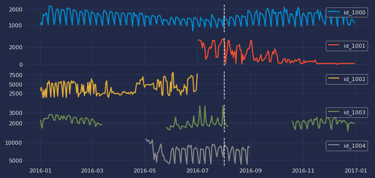

```python
# Gráfico series
# ==============================================================================
set_dark_theme()
colors = plt.rcParams['axes.prop_cycle'].by_key()['color']
fig, axs = plt.subplots(5, 1, figsize=(8, 4), sharex=True)
for i, s in enumerate(series_dict.values()):
    axs[i].plot(s, label=s.name, color=colors[i])
    axs[i].legend(loc='upper right', fontsize=8)
    axs[i].tick_params(axis='both', labelsize=8)
    axs[i].axvline(pd.to_datetime(end_train), color='white', linestyle='--', linewidth=1)
```

```python
# Descripción de cada serie
# ==============================================================================
for k in series_dict.keys():
    print(f"{k}:")
    try:
        print(
            f"\tTrain: len={len(series_dict_train[k])}, {series_dict_train[k].index[0]}"
            f" --- {series_dict_train[k].index[-1]} "
            f" (missing={series_dict_train[k].isnull().sum()})"
        )
    except:
        print(f"\tTrain: len=0")
    try:
        print(
            f"\tTest : len={len(series_dict_test[k])}, {series_dict_test[k].index[0]}"
            f" --- {series_dict_test[k].index[-1]} "
            f" (missing={series_dict_test[k].isnull().sum()})"
        )
    except:
        print(f"\tTest : len=0")
```

```
id_1000:
	Train: len=213, 2016-01-01 00:00:00 --- 2016-07-31 00:00:00  (missing=0)
	Test : len=153, 2016-08-01 00:00:00 --- 2016-12-31 00:00:00  (missing=0)
id_1001:
	Train: len=30, 2016-07-02 00:00:00 --- 2016-07-31 00:00:00  (missing=0)
	Test : len=153, 2016-08-01 00:00:00 --- 2016-12-31 00:00:00  (missing=0)
id_1002:
	Train: len=183, 2016-01-01 00:00:00 --- 2016-07-01 00:00:00  (missing=0)
	Test : len=0
id_1003:
	Train: len=213, 2016-01-01 00:00:00 --- 2016-07-31 00:00:00  (missing=73)
	Test : len=153, 2016-08-01 00:00:00 --- 2016-12-31 00:00:00  (missing=73)
id_1004:
	Train: len=91, 2016-05-02 00:00:00 --- 2016-07-31 00:00:00  (missing=0)
	Test : len=31, 2016-08-01 00:00:00 --- 2016-08-31 00:00:00  (missing=0)
```

```python
# Variables exógenas de cada serie
# ==============================================================================
for k in series_dict.keys():
    print(f"{k}:")
    try:
        print(f"\t{exog_dict[k].columns.to_list()}")
    except:
        print(f"\tNo variables exógenas")
```

```
id_1000:
	['sin_day_of_week', 'cos_day_of_week']
id_1001:
	['sin_day_of_week', 'cos_day_of_week', 'air_temperature', 'wind_speed']
id_1002:
	['sin_day_of_week', 'cos_day_of_week', 'air_temperature', 'wind_speed']
id_1003:
	['sin_day_of_week', 'air_temperature', 'wind_speed']
id_1004:
	['sin_day_of_week', 'cos_day_of_week', 'air_temperature', 'wind_speed']
```

### Modelo global: Forecaster multiseries

```python
# Fit forecaster
# ==============================================================================
regressor = HistGradientBoostingRegressor(random_state=123, max_depth=5)
window_features = RollingFeatures(stats=['mean', 'min', 'max'], window_sizes=7)
forecaster = ForecasterRecursiveMultiSeries(
                regressor          = regressor,
                lags               = 14,
                window_features    = window_features,
                encoding           = "ordinal",
                dropna_from_series = False
            )

forecaster.fit(series=series_dict_train, exog=exog_dict_train, suppress_warnings=True)
forecaster
```

ForecasterRecursiveMultiSeries

**General Information**

- **Regressor:** HistGradientBoostingRegressor(max_depth=5, random_state=123)

- **Lags:** [ 1 2 3 4 5 6 7 8 9 10 11 12 13 14]

- **Window features:** ['roll_mean_7', 'roll_min_7', 'roll_max_7']

- **Window size:** 14

- **Series encoding:** ordinal

- **Exogenous included:** True

- **Weight function included:** False

- **Series weights:** None

- **Differentiation order:** None

- **Creation date:** 2024-11-06 14:49:01

- **Last fit date:** 2024-11-06 14:49:02

- **Skforecast version:** 0.14.0

- **Python version:** 3.12.5

- **Forecaster id:** None

**Exogenous Variables**

sin_day_of_week, cos_day_of_week, air_temperature, wind_speed

**Data Transformations**

- **Transformer for series:** None

- **Transformer for exog:** None

**Training Information**

- **Series names (levels):** id_1000, id_1001, id_1002, id_1003, id_1004

- **Training range:** 'id_1000': ['2016-01-01', '2016-07-31'], 'id_1001': ['2016-07-02', '2016-07-31'], 'id_1002': ['2016-01-01', '2016-07-01'], 'id_1003': ['2016-01-01', '2016-07-31'], 'id_1004': ['2016-05-02', '2016-07-31']

- **Training index type:** DatetimeIndex

- **Training index frequency:** D

**Regressor Parameters**

{'categorical_features': 'warn', 'early_stopping': 'auto', 'interaction_cst': None, 'l2_regularization': 0.0, 'learning_rate': 0.1, 'loss': 'squared_error', 'max_bins': 255, 'max_depth': 5, 'max_features': 1.0, 'max_iter': 100, 'max_leaf_nodes': 31, 'min_samples_leaf': 20, 'monotonic_cst': None, 'n_iter_no_change': 10, 'quantile': None, 'random_state': 123, 'scoring': 'loss', 'tol': 1e-07, 'validation_fraction': 0.1, 'verbose': 0, 'warm_start': False}

**Fit Kwargs**

{}

[🛈 **API Reference**](https://skforecast.org/0.14.0/api/forecasterrecursivemultiseries.html) [🗎 **User Guide**](https://skforecast.org/0.14.0/user_guides/independent-multi-time-series-forecasting.html)

Sólo se pueden predecir juntas las series cuya última ventana de datos (*last_window*) termine en el mismo índice fecha-hora. Si `levels = None`, se excluyen de la predicción las series que no alcanzan el índice máximo. En este ejemplo, la serie `'id_1002` se excluye.

```python
# Predict
# ==============================================================================
predicciones = forecaster.predict(steps=5, exog=exog_dict_test, suppress_warnings=True)
predicciones
```

|  | id_1000 | id_1001 | id_1003 | id_1004 |
| --- | --- | --- | --- | --- |
| 2016-08-01 | 1433.494674 | 3068.244797 | 2748.768695 | 7763.964965 |
| 2016-08-02 | 1465.937652 | 3468.972018 | 2022.956989 | 8734.459604 |
| 2016-08-03 | 1407.568704 | 3475.785941 | 1860.174602 | 9111.776904 |
| 2016-08-04 | 1355.034624 | 3356.315154 | 1823.007406 | 8815.493044 |
| 2016-08-05 | 1298.820257 | 3325.735999 | 1815.224166 | 8664.891475 |

### Backtesting

Cuando las series tienen longitudes diferentes, el proceso de backtesting sólo devuelve predicciones para las fechas-horas que están presentes en las series.

```python
# Backtesting
# ==============================================================================
cv = TimeSeriesFold(
        steps              = 24,
        initial_train_size = len(series_dict_train["id_1000"]),
        refit              = False,
     )

metrics_levels, backtest_predictions = backtesting_forecaster_multiseries(
    forecaster            = forecaster,
    series                = series_dict,
    exog                  = exog_dict,
    cv                    = cv,
    metric                = "mean_absolute_error",
    add_aggregated_metric = False,
    n_jobs                = "auto",
    verbose               = True,
    show_progress         = True,
    suppress_warnings     = True
)

display(metrics_levels)
display(backtest_predictions)
```

```
Information of folds
--------------------
Number of observations used for initial training: 213
Number of observations used for backtesting: 153
    Number of folds: 7
    Number skipped folds: 0
    Number of steps per fold: 24
    Number of steps to exclude between last observed data (last window) and predictions (gap): 0
    Last fold only includes 9 observations.

Fold: 0
    Training:   2016-01-01 00:00:00 -- 2016-07-31 00:00:00  (n=213)
    Validation: 2016-08-01 00:00:00 -- 2016-08-24 00:00:00  (n=24)
Fold: 1
    Training:   No training in this fold
    Validation: 2016-08-25 00:00:00 -- 2016-09-17 00:00:00  (n=24)
Fold: 2
    Training:   No training in this fold
    Validation: 2016-09-18 00:00:00 -- 2016-10-11 00:00:00  (n=24)
Fold: 3
    Training:   No training in this fold
    Validation: 2016-10-12 00:00:00 -- 2016-11-04 00:00:00  (n=24)
Fold: 4
    Training:   No training in this fold
    Validation: 2016-11-05 00:00:00 -- 2016-11-28 00:00:00  (n=24)
Fold: 5
    Training:   No training in this fold
    Validation: 2016-11-29 00:00:00 -- 2016-12-22 00:00:00  (n=24)
Fold: 6
    Training:   No training in this fold
    Validation: 2016-12-23 00:00:00 -- 2016-12-31 00:00:00  (n=9)
```

|  | levels | mean_absolute_error |
| --- | --- | --- |
| 0 | id_1000 | 164.959423 |
| 1 | id_1001 | 1055.559754 |
| 2 | id_1002 | NaN |
| 3 | id_1003 | 235.663130 |
| 4 | id_1004 | 968.459237 |

|  | id_1000 | id_1001 | id_1003 | id_1004 |
| --- | --- | --- | --- | --- |
| 2016-08-01 | 1433.494674 | 3068.244797 | 2748.768695 | 7763.964965 |
| 2016-08-02 | 1465.937652 | 3468.972018 | 2022.956989 | 8734.459604 |
| 2016-08-03 | 1407.568704 | 3475.785941 | 1860.174602 | 9111.776904 |
| 2016-08-04 | 1355.034624 | 3356.315154 | 1823.007406 | 8815.493044 |
| 2016-08-05 | 1298.820257 | 3325.735999 | 1815.224166 | 8664.891475 |
| ... | ... | ... | ... | ... |
| 2016-12-27 | 1712.239821 | 1083.974921 | 2069.136527 | NaN |
| 2016-12-28 | 1622.091030 | 1015.958815 | 1984.614144 | NaN |
| 2016-12-29 | 1555.862159 | 1085.108004 | 1909.150202 | NaN |
| 2016-12-30 | 1513.901694 | 1114.592910 | 1965.060657 | NaN |
| 2016-12-31 | 1459.122750 | 1001.655092 | 1969.768680 | NaN |

153 rows × 4 columns

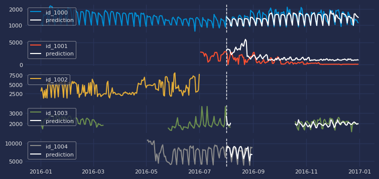

```python
# Gráfico predicciones backtesting
# ==============================================================================
colors = plt.rcParams['axes.prop_cycle'].by_key()['color']
fig, axs = plt.subplots(5, 1, figsize=(8, 4), sharex=True)
for i, s in enumerate(series_dict.keys()):
    axs[i].plot(series_dict[s], label=series_dict[s].name, color=colors[i])
    axs[i].axvline(pd.to_datetime(end_train), color='white', linestyle='--', linewidth=1)
    try:
        axs[i].plot(backtest_predictions[s], label='prediction', color="white")
    except:
        pass
    axs[i].legend(loc='upper left', fontsize=8)
    axs[i].tick_params(axis='both', labelsize=8)
```

Al permitir la modelización de series temporales de diferentes longitudes y con diferentes variables exógenas, la clase [ForecasterRecursiveMultiSeries](https://skforecast.org/latest/user_guides/independent-multi-time-series-forecasting) proporciona una herramienta flexible y potente para utilizar toda la información disponible para entrenar los modelos.

## Optimización de hiperparámetros (tuning) y selección de lags

**🖉 Note**

Optimizar los hiperparámetros de múltiples modelos puede ser computacionalmente costoso. Para acelerar el proceso, la evaluación de cada configuración candidata se realiza utilizando *one-step-ahead* en lugar de *backtesting*. Para más detalles sobre las ventajas y limitaciones de este enfoque, consulte [One-step-ahead validation](https://skforecast.org/latest/user_guides/hyperparameter-tuning-and-lags-selection#one-step-ahead-validation.html).

```python
# Búsqueda de hiperparámetros y backtesting de un modelo para cada item
# ======================================================================================
warnings.simplefilter('ignore', category=OneStepAheadValidationWarning)
items = []
mae_values  = []

def search_space(trial):
    search_space  = {
        'lags'          : trial.suggest_categorical('lags', [7, 14]),
        'max_iter'      : trial.suggest_int('max_iter', 100, 500),
        'max_depth'     : trial.suggest_int('max_depth', 5, 10),
        'learning_rate' : trial.suggest_float('learning_rate', 0.01, 0.1)
    }

    return search_space

for item in tqdm(data.columns):

    window_features = RollingFeatures(stats=['mean', 'min', 'max'], window_sizes=7)
    forecaster = ForecasterRecursive(
                    regressor       = HistGradientBoostingRegressor(random_state=123),
                    lags            = 14,
                    window_features = window_features
                )

    cv_search = OneStepAheadFold(initial_train_size = len(data_train))

    warnings.simplefilter('ignore', category=OneStepAheadValidationWarning)
    results_bayesian = bayesian_search_forecaster(
                        forecaster    = forecaster,
                        y             = data.loc[:end_val, item],
                        cv            = cv_search,
                        search_space  = search_space,
                        n_trials      = 20,
                        metric        = 'mean_absolute_error',
                        return_best   = True,
                        verbose       = False,
                        show_progress = False
                    )

    cv_backtesting = TimeSeriesFold(
                        steps              = 7,
                        initial_train_size = len(data_train) + len(data_val),
                        refit              = False,
                        )
    metric, preds = backtesting_forecaster(
                        forecaster    = forecaster,
                        y             = data[item],
                        cv            = cv_backtesting,
                        metric        = 'mean_absolute_error',
                        verbose       = False,
                        show_progress = False
                    )

    items.append(item)
    mae_values.append(metric.at[0, 'mean_absolute_error'])

uni_series_mae = pd.Series(
                    data  = mae_values,
                    index = items,
                    name  = 'uni_series_mae'
                )
```

```python
# Busqueda de hiperparámetros y backtesting de un modelo global para todos los items
# ======================================================================================
def search_space(trial):
    search_space  = {
        'lags'          : trial.suggest_categorical('lags', [7, 14]),
        'max_iter'      : trial.suggest_int('max_iter', 100, 500),
        'max_depth'     : trial.suggest_int('max_depth', 5, 10),
        'learning_rate' : trial.suggest_float('learning_rate', 0.01, 0.1)
    }

    return search_space

forecaster_ms = ForecasterRecursiveMultiSeries(
                    regressor          = HistGradientBoostingRegressor(random_state=123),
                    lags               = 14,
                    transformer_series = StandardScaler(),
                    encoding           = 'ordinal'
                )

results_bayesian_ms = bayesian_search_forecaster_multiseries(
                        forecaster    = forecaster_ms,
                        series        = data.loc[:end_val, :],
                        levels        = None, # Si es None se seleccionan todos los niveles
                        cv            = cv_search,
                        search_space  = search_space,
                        n_trials      = 20,
                        metric        = 'mean_absolute_error',
                        return_best   = True,
                        verbose       = False,
                        show_progress = False
                    )

multi_series_mae, predictions_ms = backtesting_forecaster_multiseries(
                                       forecaster            = forecaster_ms,
                                       series                = data,
                                       levels                = None, # Si es None se seleccionan todos los niveles
                                       cv                    = cv_backtesting,
                                       metric                = 'mean_absolute_error',
                                       add_aggregated_metric = False,
                                       verbose               = False
                                   )
```

```
`Forecaster` refitted using the best-found lags and parameters, and the whole data set:
  Lags: [ 1  2  3  4  5  6  7  8  9 10 11 12 13 14]
  Parameters: {'max_iter': 352, 'max_depth': 9, 'learning_rate': 0.034448731526687745}
  Backtesting metric: 8.015025437227383
  Levels: ['item_1', 'item_2', 'item_3', 'item_4', 'item_5', 'item_6', 'item_7', 'item_8', 'item_9', 'item_10', 'item_11', 'item_12', 'item_13', 'item_14', 'item_15', 'item_16', 'item_17', 'item_18', 'item_19', 'item_20', 'item_21', 'item_22', 'item_23', 'item_24', 'item_25', 'item_26', 'item_27', '…
```

```python
# Diferencia de la métrica de backtesting para cada item
# ======================================================================================
multi_series_mae = multi_series_mae.set_index('levels')
multi_series_mae.columns = ['multi_series_mae']
results = pd.concat((uni_series_mae, multi_series_mae), axis = 1)
results['improvement'] = results.eval('uni_series_mae - multi_series_mae')
results['improvement_(%)'] = 100 * results.eval('(uni_series_mae - multi_series_mae) / uni_series_mae')
results = results.round(2)

# Mejora media de todos los items
# ======================================================================================
results[['improvement', 'improvement_(%)']].agg(['mean', 'min', 'max'])
```

|  | improvement | improvement_(%) |
| --- | --- | --- |
| mean | 0.5018 | 5.3168 |
| min | -0.0400 | -0.7900 |
| max | 1.5100 | 13.1900 |

```python
# Número de series con mejora positiva y negativa
# ======================================================================================
pd.Series(np.where(results['improvement_(%)'] < 0, 'negative', 'positive')).value_counts()
```

```
positive    48
negative     2
Name: count, dtype: int64
```

Tras identificar la combinación de *lags* e hiperparámetros que logran el mejor rendimiento predictivo para cada *forecaster*, un número superior de modelos univariantes han logrado una mayor capacidad predictiva. Aun así, el modelo multiserie proporciona mejores resultados para la mayoría de los items.

## Selección de predictores

La selección de predictores es el proceso de seleccionar un subconjunto de predictores relevantes (variables) para su uso en la construcción del modelo. Las técnicas de selección de predictores se utilizan por varias razones: para simplificar los modelos y hacerlos más fáciles de interpretar, para reducir el tiempo de entrenamiento, para evitar los problemas de dimensionalidad, para mejorar la generalización reduciendo el sobreajuste (formalmente, la reducción de la varianza), entre otros.

Skforecast es compatible con los [métodos de selección implementados en scikit-learn](https://scikit-learn.org/stable/modules/feature_selection.html). Existen varios métodos de selección de características, pero los más comunes son:

- Recursive feature elimination (RFE)
- Sequential Feature Selection (SFS)
- Feature selection based on threshold (SelectFromModel)

**💡 Tip**

La selección de predictores es una herramienta poderosa para mejorar el rendimiento de los modelos de machine learning. Sin embargo, es computacionalmente costosa y puede llevar tiempo. Dado que el objetivo es encontrar el mejor subconjunto de variables, no el mejor modelo, no es necesario utilizar todo el conjunto de datos o un modelo muy complejo. En su lugar, se recomienda utilizar un **pequeño subconjunto de datos y un modelo simple**. Una vez que se haya identificado el mejor subconjunto de variables, el modelo puede entrenarse utilizando todo el conjunto de datos y una configuración más compleja.

## Pesos en forecasting multiseries

Los pesos se utilizan para controlar la influencia que tiene cada observación en el entrenamiento del modelo. `ForecasterAutoregMultiseries` acepta dos tipos de pesos:

- `series_weights` controla la importancia relativa de cada serie. Si una serie tiene el doble de peso que las demás, las observaciones de esa serie influyen el doble en el entrenamiento. Cuanto mayor sea el peso de una serie en relación con las demás, más se centrará el modelo en intentar aprender esa serie.
- `weight_func` controla la importancia relativa de cada observación en función del índice. Por ejemplo, una función que asigna un peso menor a ciertas fechas.

Si se indican los dos tipos de pesos, estos se **multiplican para crear los pesos finales** como se muestra en la figura. El `sample_weight` resultante no puede contener valores negativos.

[figure not shown]

Más información sobre [weights in multi-series forecasting](https://skforecast.org/latest/user_guides/independent-multi-time-series-forecasting.html#weights-in-multi-series) y [weighted time series forecasting](https://skforecast.org/latest/user_guides/weighted-time-series-forecasting.html) con skforecast.

En este ejemplo, `item_1` tiene una mayor importancia relativa entre series (pesa 3 veces más que el resto de series), y las observaciones entre '2013-12-01' y '2014-01-31' se consideran no representativas y se les aplica un peso de 0.

```python
# Pesos en forecasting multiseries
# ======================================================================================
# Pesos de cada serie
series_weights = {'item_1': 3.0} # Las series que no aparezcan en el dict tienen un peso de 1

# Pesos de cada observación (por índice)
def custom_weights(index):
    """
    Devuelve 0 si el índice está entre '2013-12-01' y '2014-01-31', 1 en caso contrario.
    """
    weights = np.where(
                  (index >= '2013-12-01') & (index <= '2014-01-31'),
                   0,
                   1
              )

    return weights

forecaster = ForecasterRecursiveMultiSeries(
                 regressor          = HistGradientBoostingRegressor(random_state=123),
                 lags               = 14,
                 transformer_series = StandardScaler(),
                 transformer_exog   = None,
                 weight_func        = custom_weights,
                 series_weights     = series_weights
             )

forecaster.fit(series=data)
forecaster.predict(steps=7).head(3)
```

|  | item_1 | item_10 | item_11 | item_12 | item_13 | item_14 | item_15 | item_16 | item_17 | item_18 | ... | item_46 | item_47 | item_48 | item_49 | item_5 | item_50 | item_6 | item_7 | item_8 | item_9 |
| --- | --- | --- | --- | --- | --- | --- | --- | --- | --- | --- | --- | --- | --- | --- | --- | --- | --- | --- | --- | --- | --- |
| 2018-01-01 | 20.583876 | 61.580282 | 62.323468 | 62.581761 | 79.205140 | 56.450206 | 85.846570 | 22.718565 | 32.502652 | 79.377183 | ... | 53.421299 | 22.260726 | 47.144927 | 28.682841 | 22.372861 | 63.199237 | 53.271716 | 57.232493 | 68.655821 | 41.978625 |
| 2018-01-02 | 22.501538 | 71.421524 | 75.349079 | 75.283254 | 89.691063 | 59.121550 | 90.118244 | 24.848422 | 36.265055 | 87.467801 | ... | 62.983381 | 26.943935 | 51.961949 | 34.340793 | 19.502197 | 63.945234 | 57.812538 | 61.734525 | 82.100161 | 49.326013 |
| 2018-01-03 | 20.907183 | 73.185299 | 76.323151 | 75.547258 | 83.861397 | 63.508950 | 95.531382 | 25.331899 | 33.468072 | 90.110389 | ... | 62.890533 | 25.834892 | 52.942216 | 32.730445 | 18.498621 | 71.040223 | 61.123112 | 63.709698 | 84.395482 | 50.310361 |

3 rows × 50 columns

## Conclusiones

Este caso de uso muestra como un modelo multiserie puede presentar ventajas sobre varios modelos individuales cuando se predicen series temporales con una dinámica similar. Más allá de las posibles mejoras en la predicción, también es importante tener en cuenta la ventaja de tener un solo modelo que mantener.

## Información de sesión

```python
import session_info
session_info.show(html=False)
```

```
-----
matplotlib          3.9.2
numpy               2.0.2
pandas              2.2.3
session_info        1.0.0
skforecast          0.14.0
sklearn             1.5.1
tqdm                4.66.5
-----
IPython             8.27.0
jupyter_client      8.6.3
jupyter_core        5.7.2
notebook            6.4.12
-----
Python 3.12.5 | packaged by Anaconda, Inc. | (main, Sep 12 2024, 18:27:27) [GCC 11.2.0]
Linux-5.15.0-1071-aws-x86_64-with-glibc2.31
-----
Session information updated at 2024-11-06 15:28
```

## Instrucciones para citar

**¿Cómo citar este documento?**

Si utilizas este documento o alguna parte de él, te agradecemos que lo cites. ¡Muchas gracias!

Modelos de forecasting globales: modelado de múltiples series temporales con machine learning por Joaquín Amat Rodrigo and Javier Escobar Ortiz, disponible con licencia Attribution-NonCommercial-ShareAlike 4.0 International (CC BY-NC-SA 4.0 DEED) en https://www.cienciadedatos.net/documentos/py44-multi-series-forecasting-skforecast-español.html

**¿Cómo citar skforecast?**

Si utilizas skforecast en tu investigación o publicación, te lo agradeceríamos mucho que lo cites. ¡Muchas gracias!

Zenodo:

Amat Rodrigo, Joaquin, & Escobar Ortiz, Javier. (2024). skforecast (v0.14.0). Zenodo. https://doi.org/10.5281/zenodo.8382788

APA:

Amat Rodrigo, J., & Escobar Ortiz, J. (2024). skforecast (Version 0.14.0) [Computer software]. https://doi.org/10.5281/zenodo.8382788

BibTeX:

@software{skforecast, author = {Amat Rodrigo, Joaquin and Escobar Ortiz, Javier}, title = {skforecast}, version = {0.14.0}, month = {11}, year = {2024}, license = {BSD-3-Clause}, url = {https://skforecast.org/}, doi = {10.5281/zenodo.8382788} }

Este material creado por Joaquín Amat Rodrigo y Javier Escobar Ortiz tiene licencia [Attribution-NonCommercial-ShareAlike 4.0 International](https://creativecommons.org/licenses/by-nc-sa/4.0/).